# Distribution of Ford GoBike Trips Based on Time of Day, Day of Week and Riders(Users).

## by Robert Gitahi

## Investigation Overview

In this investigation, I wanted to look at how the duration of bike trips are affected by certain variables. The variables in question are time of day, day of the week and type of user.

## Dataset Overview

The data consists of information regarding 183,411 rides made in a bike-sharing system covering the greater San Francisco Bay area. The dataset contains 18 columns and 183411 records/rows. 9 numerical, 2 string/object, 3 boolean datatypes and 2 datetime.

## Trip Distribution in Seconds

The trip duration dataset was plotted on a logarithmic scale due to the large range of values. On the logarithmic scale the distribution takes a normal distribution shape.

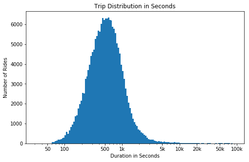

## Trip Distributionper Days of the week

Most bike trips happened on Thursdays followed by Tuesdays. Wednesday, Friday and Monday seem to be close in terms of bike trips. Saturday and Sunday has the lowest number of bike trips.

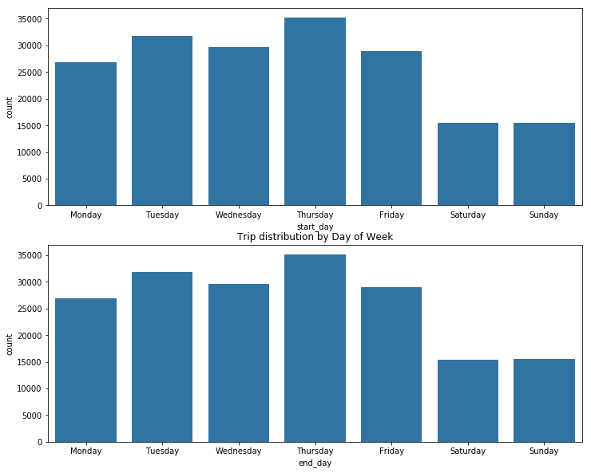

## Trip Distribution per Hour of Day

The highest recorded trip times are in the 8th - 9th and 17th - 18th hour of the day. The lowest activity happens between the hours of 0000hrs - 0500hrs. Based on this observation, we can deduce that the peak hours are rush hours when users are trying to get ot work or are coming from work.

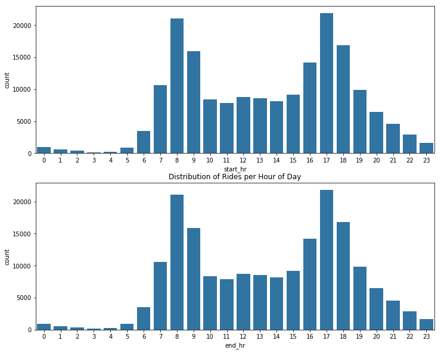

## Trip Distribution by Gender

This observation shows that the females and other gender take a slighlty longer time the males for the rides.

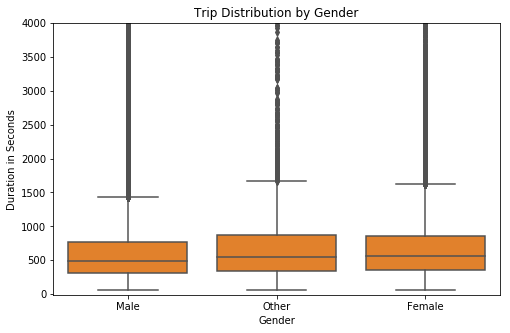

## Trip Distribution by User Type

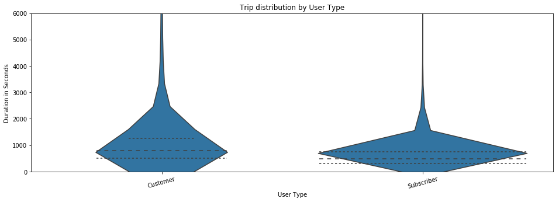